# Case study on how can a wellness company play it smart

Nikhil Sharma

2022-08-11

# Data Analytics For How can a wellness company play it smart? A Case Study

**Nikhil Sharma**  
Center for computer and Communication Technology, Chisopani, Sikkim  
Google/ Data Analytics Professional Certificate - Coursera

#### Keywords:

Data Analytics, bellabeat, wellness, Case Study

## 1. Introduction

This exploratory analysis case study is towards Capstone project requirement for Google Data Analytics Professional Certificate. The case study involve to analyze a smart device data to gain insight into how consumers are using their smart devices.The insights I discover will then help guide marketing strategy for the company. The dataset has been made available by a Public Domain, [Mobius](https://www.kaggle.com/arashnic)

The analysis will follow the 6 phases of the Data Analysis process by the Google: Ask, Prepare, Process, Analyze, Share, and Act.

#### 1.1 A brief explanation of these 6 phases:

###### Ask

- Ask effective questions
- Define the scope of the analysis
- Define what success looks like

###### Prepare

- Verify data’s integrity
- Check data credibility and reliability
- Check data types
- Merge datasets

###### Process

- Clean, Remove and Transform data
- Document cleaning processes and results

###### Analyze

- Identify patterns
- Draw conclusions
- Make predictions

###### Share

- Create effective visuals
- Create a story for data
- Share insights to stakeholders

###### Act

- Give recommendations based on insights
- Solve problems
- Create something new

## 2. Business Understanding

The focus of this section is to understand the basic concepts of our wellness company ‘Bellabeat’. Project objectives are derived from the Director of Marketing and later converted into data science problem definitions.

#### 2.1 Scenario’

**Please note that this is a fictional case study.**

Urška Sršen and Sando Mur founded Bellabeat, a high-tech company that manufactures health-focused smart products. Sršen used her background as an artist to develop beautifully designed technology that informs and inspires women around the world. Collecting data on activity, sleep, stress, and reproductive health has allowed Bellabeat to empower women with knowledge about their own health and habits. Since it was founded in 2013, Bellabeat has grown rapidly and quickly positioned itself as a tech-driven wellness company for women.

By 2016, Bellabeat had opened offices around the world and launched multiple products. Bellabeat products became available through a growing number of online retailers in addition to their own e-commerce channel on their website. The company has invested in traditional advertising media, such as radio, out-of-home billboards, print, and television, but focuses on digital marketing extensively. Bellabeat invests year-round in Google Search, maintaining active Facebook and Instagram pages, and consistently engages consumers on Twitter. Additionally, Bellabeat runs video ads on Youtube and display ads on the Google Display Network to support campaigns around key marketing dates.

Sršen knows that an analysis of Bellabeat’s available consumer data would reveal more opportunities for growth. She has asked the marketing analytics team to focus on a Bellabeat product and analyze smart device usage data in order to gain insight into how people are already using their smart devices. Then, using this information, she would like high-level recommendations for how these trends can inform Bellabeat marketing strategy

#### 2.2 Stakeholders

- Urška Sršen: Bellabeat’s cofounder and Chief Creative Officer
- Sando Mur: Mathematician and Bellabeat’s cofounder; key member of the Bellabeat executive team

#### 2.3 Objective

Hence, the objective for this analysis is to give a proper insight of how non-bellabeat use smart devices and apply it to one of the bellabeat products. It would helpfull for Bellabeat marketing strategy.

## 3. Data Understanding

This section starts with initial data collection and proceeds with activities that targets understanding the data. These activities include ﬁrst insight into the data, identifying data for analytic purposes, discovering data quality issues and/or detecting interesting subsets to form hypothesis regarding previously un-detected patterns.

#### 3.1 Data Source, Licensing, Privacy

Would like to thank Möbius for providing this relevant dataset to conduct this smart wellness device usage and its trending

Thirty eligible Fitbit users consented to the submission of personal tracker data, including minute-level output for physical activity, heart rate, and sleep monitoring.

#### 3.3 Documentation, Cleaning and Preparation of data for analysis

The combined size of all the 18 datasets which is massive in size. Data cleaning in spreadsheets will be time-consuming and slow compared to SQL or R. I am choosing R simply because I could do both data wrangling and analysis/ visualizations in the same platform. It is also an opportunity for me to learn R in a better way.

## 4. Data Preparation

This section provides insight into the business problems before performing data modeling. The data preparation phase include activities, such as data selection, data transformation, data cleaning and data validation. Data preparation tasks may be performed several times and not in any given order. During this phase important issues are addressed like selecting the relevant data, cleaning of data, discarding unacceptable data and how the ERP system data can be integrated into the ﬁnal data sets.

#### 4.1 Loading Datsets

```r
library(tidyverse)
```

```r
library(ggplot2)
library(lubridate)
library(dplyr)
library(geosphere)
library(readr)
library(janitor)
library(data.table)
library(tidyr)
library(scales)
```

#### 4.2 Load the 18 Datasets in their respective variable name

The 18 health-focused data(in CSV format) are extracted and stored in one folder titled “fitbase-data”.

```r
  daily_activity <- read.csv("../fitbase_data/dailyActivity_merged.csv")
  daily_calories <- read.csv("../fitbase_data/dailyCalories_merged.csv")
  daily_intensities <- read.csv("../fitbase_data/dailyIntensities_merged.csv")
  daily_steps <- read.csv("../fitbase_data/dailySteps_merged.csv")

  heartrate_seconds <- read.csv("../fitbase_data/heartrate_seconds_merged.csv")
  hourly_calories <- read.csv("../fitbase_data/hourlyCalories_merged.csv")
  hourly_intensities <- read.csv("../fitbase_data/hourlyIntensities_merged.csv")
  hourly_steps <- read.csv("../fitbase_data/hourlySteps_merged.csv")

  minute_calories_narrow <- read.csv("../fitbase_data/minuteCaloriesNarrow_merged.csv")
  minute_calories_wide <- read.csv("../fitbase_data/minuteCaloriesWide_merged.csv")
  minute_intensities_narrow <- read.csv("../fitbase_data/minuteIntensitiesNarrow_merged.csv")
  minute_intensities_wide <- read.csv("../fitbase_data/minuteIntensitiesWide_merged.csv")

  minute_METs_narrow <- read.csv("../fitbase_data/minuteMETsNarrow_merged.csv")
  minute_sleep <- read.csv("../fitbase_data/minuteSleep_merged.csv")
  minute_steps_narrow <- read.csv("../fitbase_data/minuteStepsNarrow_merged.csv")
  minute_steps_wide <- read.csv("../fitbase_data/minuteStepsWide_merged.csv")

   sleep_day <- read.csv("../fitbase_data/sleepDay_merged.csv")
  weight_log_info <- read.csv("../fitbase_data/weightLogInfo_merged.csv")
```

#### 4.3 Check data structures and data types for all data frames for data integrity

```r
head(daily_activity)
```

[output not shown]

```r
head(daily_calories)
```

```
##           Id ActivityDay Calories
## 1 1503960366   4/12/2016     1985
## 2 1503960366   4/13/2016     1797
## 3 1503960366   4/14/2016     1776
## 4 1503960366   4/15/2016     1745
## 5 1503960366   4/16/2016     1863
## 6 1503960366   4/17/2016     1728
```

```r
head(daily_intensities)
```

```
##           Id ActivityDay SedentaryMinutes LightlyActiveMinutes
## 1 1503960366   4/12/2016              728                  328
## 2 1503960366   4/13/2016              776                  217
## 3 1503960366   4/14/2016             1218                  181
## 4 1503960366   4/15/2016              726                  209
## 5 1503960366   4/16/2016              773                  221
## 6 1503960366   4/17/2016              539                  164
##   FairlyActiveMinutes VeryActiveMinutes SedentaryActiveDistance
## 1                  13                25                       0
## 2                  19                21                       0
## 3                  11                30                       0
## 4                  34                29                       0
## 5                  10                36                       0
## 6                  20                38                       0
##   LightActiveDistance ModeratelyActiveDistance VeryActiveDistance
## 1                6.06                     0.55               1.88
## 2                4.71                     0.69               1.57
## 3                3.91                     0.40               2.44
## 4                2.83                     1.26               2.14
## 5                5.04                     0.41               2.71
## 6                2.51                     0.78               3.19
```

```r
head(daily_steps)
```

```
##           Id ActivityDay StepTotal
## 1 1503960366   4/12/2016     13162
## 2 1503960366   4/13/2016     10735
## 3 1503960366   4/14/2016     10460
## 4 1503960366   4/15/2016      9762
## 5 1503960366   4/16/2016     12669
## 6 1503960366   4/17/2016      9705
```

```r
head(heartrate_seconds)
```

```
##           Id                 Time Value
## 1 2022484408 4/12/2016 7:21:00 AM    97
## 2 2022484408 4/12/2016 7:21:05 AM   102
## 3 2022484408 4/12/2016 7:21:10 AM   105
## 4 2022484408 4/12/2016 7:21:20 AM   103
## 5 2022484408 4/12/2016 7:21:25 AM   101
## 6 2022484408 4/12/2016 7:22:05 AM    95
```

```r
head(hourly_calories)
```

```
##           Id          ActivityHour Calories
## 1 1503960366 4/12/2016 12:00:00 AM       81
## 2 1503960366  4/12/2016 1:00:00 AM       61
## 3 1503960366  4/12/2016 2:00:00 AM       59
## 4 1503960366  4/12/2016 3:00:00 AM       47
## 5 1503960366  4/12/2016 4:00:00 AM       48
## 6 1503960366  4/12/2016 5:00:00 AM       48
```

```r
head(hourly_intensities)
```

```
##           Id          ActivityHour TotalIntensity AverageIntensity
## 1 1503960366 4/12/2016 12:00:00 AM             20         0.333333
## 2 1503960366  4/12/2016 1:00:00 AM              8         0.133333
## 3 1503960366  4/12/2016 2:00:00 AM              7         0.116667
## 4 1503960366  4/12/2016 3:00:00 AM              0         0.000000
## 5 1503960366  4/12/2016 4:00:00 AM              0         0.000000
## 6 1503960366  4/12/2016 5:00:00 AM              0         0.000000
```

```r
head(hourly_steps)
```

```
##           Id          ActivityHour StepTotal
## 1 1503960366 4/12/2016 12:00:00 AM       373
## 2 1503960366  4/12/2016 1:00:00 AM       160
## 3 1503960366  4/12/2016 2:00:00 AM       151
## 4 1503960366  4/12/2016 3:00:00 AM         0
## 5 1503960366  4/12/2016 4:00:00 AM         0
## 6 1503960366  4/12/2016 5:00:00 AM         0
```

```r
head(minute_calories_narrow)
```

```
##           Id        ActivityMinute Calories
## 1 1503960366 4/12/2016 12:00:00 AM   0.7865
## 2 1503960366 4/12/2016 12:01:00 AM   0.7865
## 3 1503960366 4/12/2016 12:02:00 AM   0.7865
## 4 1503960366 4/12/2016 12:03:00 AM   0.7865
## 5 1503960366 4/12/2016 12:04:00 AM   0.7865
## 6 1503960366 4/12/2016 12:05:00 AM   0.9438
```

```r
head(minute_calories_wide)
```

```
##           Id          ActivityHour Calories00 Calories01 Calories02 Calories03
## 1 1503960366 4/13/2016 12:00:00 AM     1.8876     2.2022     0.9438     0.9438
## 2 1503960366  4/13/2016 1:00:00 AM     0.7865     0.7865     0.7865     0.7865
## 3 1503960366  4/13/2016 2:00:00 AM     0.7865     0.7865     0.7865     0.7865
## 4 1503960366  4/13/2016 3:00:00 AM     0.7865     0.7865     0.7865     0.7865
## 5 1503960366  4/13/2016 4:00:00 AM     0.7865     0.7865     0.7865     0.7865
## 6 1503960366  4/13/2016 5:00:00 AM     0.7865     0.7865     0.7865     0.7865
##   Calories04 Calories05 Calories06 Calories07 Calories08 Calories09 Calories10
## 1     0.9438     2.0449     0.9438     2.2022     0.9438     0.7865     0.9438
## 2     0.9438     0.9438     0.9438     0.7865     0.9438     0.7865     0.9438
## 3     0.7865     0.7865     0.7865     0.7865     0.7865     0.7865     0.7865
## 4     0.7865     0.7865     0.7865     0.7865     0.7865     0.7865     0.7865
## 5     0.7865     0.7865     0.7865     0.7865     0.7865     0.7865     0.7865
## 6     0.7865     0.7865     0.7865     0.7865     0.7865     0.7865     0.7865
##   Calories11 Calories12 Calories13 Calories14 Calories15 Calories16 Calories17
```

[output cut: 48 more lines]

```r
head(minute_intensities_narrow)
```

```
##           Id        ActivityMinute Intensity
## 1 1503960366 4/12/2016 12:00:00 AM         0
## 2 1503960366 4/12/2016 12:01:00 AM         0
## 3 1503960366 4/12/2016 12:02:00 AM         0
## 4 1503960366 4/12/2016 12:03:00 AM         0
## 5 1503960366 4/12/2016 12:04:00 AM         0
## 6 1503960366 4/12/2016 12:05:00 AM         0
```

```r
head(minute_intensities_wide)
```

```
##           Id          ActivityHour Intensity00 Intensity01 Intensity02
## 1 1503960366 4/13/2016 12:00:00 AM           1           1           0
## 2 1503960366  4/13/2016 1:00:00 AM           0           0           0
## 3 1503960366  4/13/2016 2:00:00 AM           0           0           0
## 4 1503960366  4/13/2016 3:00:00 AM           0           0           0
## 5 1503960366  4/13/2016 4:00:00 AM           0           0           0
## 6 1503960366  4/13/2016 5:00:00 AM           0           0           0
##   Intensity03 Intensity04 Intensity05 Intensity06 Intensity07 Intensity08
## 1           0           0           1           0           1           0
## 2           0           0           0           0           0           0
## 3           0           0           0           0           0           0
## 4           0           0           0           0           0           0
## 5           0           0           0           0           0           0
## 6           0           0           0           0           0           0
##   Intensity09 Intensity10 Intensity11 Intensity12 Intensity13 Intensity14
```

[output cut: 62 more lines]

```r
head(minute_METs_narrow)
```

```
##           Id        ActivityMinute METs
## 1 1503960366 4/12/2016 12:00:00 AM   10
## 2 1503960366 4/12/2016 12:01:00 AM   10
## 3 1503960366 4/12/2016 12:02:00 AM   10
## 4 1503960366 4/12/2016 12:03:00 AM   10
## 5 1503960366 4/12/2016 12:04:00 AM   10
## 6 1503960366 4/12/2016 12:05:00 AM   12
```

```r
head(minute_sleep)
```

```
##           Id                 date value       logId
## 1 1503960366 4/12/2016 2:47:30 AM     3 11380564589
## 2 1503960366 4/12/2016 2:48:30 AM     2 11380564589
## 3 1503960366 4/12/2016 2:49:30 AM     1 11380564589
## 4 1503960366 4/12/2016 2:50:30 AM     1 11380564589
## 5 1503960366 4/12/2016 2:51:30 AM     1 11380564589
## 6 1503960366 4/12/2016 2:52:30 AM     1 11380564589
```

```r
head(minute_steps_narrow)
```

```
##           Id        ActivityMinute Steps
## 1 1503960366 4/12/2016 12:00:00 AM     0
## 2 1503960366 4/12/2016 12:01:00 AM     0
## 3 1503960366 4/12/2016 12:02:00 AM     0
## 4 1503960366 4/12/2016 12:03:00 AM     0
## 5 1503960366 4/12/2016 12:04:00 AM     0
## 6 1503960366 4/12/2016 12:05:00 AM     0
```

```r
head(minute_steps_wide)
```

```
##           Id          ActivityHour Steps00 Steps01 Steps02 Steps03 Steps04
## 1 1503960366 4/13/2016 12:00:00 AM       4      16       0       0       0
## 2 1503960366  4/13/2016 1:00:00 AM       0       0       0       0       0
## 3 1503960366  4/13/2016 2:00:00 AM       0       0       0       0       0
## 4 1503960366  4/13/2016 3:00:00 AM       0       0       0       0       0
## 5 1503960366  4/13/2016 4:00:00 AM       0       0       0       0       0
## 6 1503960366  4/13/2016 5:00:00 AM       0       0       0       0       0
##   Steps05 Steps06 Steps07 Steps08 Steps09 Steps10 Steps11 Steps12 Steps13
## 1       9       0      17       0       0       0       0       0       0
## 2       0       0       0       0       0       0       0       0       0
## 3       0       0       0       0       0       0       0       0       0
## 4       0       0       0       0       0       0      10       0       0
## 5       0       0       0       0       0       0       0       0       0
## 6       0       0       0       0       0       0       0       0       0
##   Steps14 Steps15 Steps16 Steps17 Steps18 Steps19 Steps20 Steps21 Steps22
```

[output cut: 41 more lines]

```r
head(sleep_day)
```

```
##           Id              SleepDay TotalSleepRecords TotalMinutesAsleep
## 1 1503960366 4/12/2016 12:00:00 AM                 1                327
## 2 1503960366 4/13/2016 12:00:00 AM                 2                384
## 3 1503960366 4/15/2016 12:00:00 AM                 1                412
## 4 1503960366 4/16/2016 12:00:00 AM                 2                340
## 5 1503960366 4/17/2016 12:00:00 AM                 1                700
## 6 1503960366 4/19/2016 12:00:00 AM                 1                304
##   TotalTimeInBed
## 1            346
## 2            407
## 3            442
## 4            367
## 5            712
## 6            320
```

```r
head(weight_log_info)
```

```
##           Id                  Date WeightKg WeightPounds Fat   BMI
## 1 1503960366  5/2/2016 11:59:59 PM     52.6     115.9631  22 22.65
## 2 1503960366  5/3/2016 11:59:59 PM     52.6     115.9631  NA 22.65
## 3 1927972279  4/13/2016 1:08:52 AM    133.5     294.3171  NA 47.54
## 4 2873212765 4/21/2016 11:59:59 PM     56.7     125.0021  NA 21.45
## 5 2873212765 5/12/2016 11:59:59 PM     57.3     126.3249  NA 21.69
## 6 4319703577 4/17/2016 11:59:59 PM     72.4     159.6147  25 27.45
##   IsManualReport        LogId
## 1           True 1.462234e+12
## 2           True 1.462320e+12
## 3          False 1.460510e+12
## 4           True 1.461283e+12
## 5           True 1.463098e+12
## 6           True 1.460938e+12
```

The following 3 datasets will be used for trend analysis:

- dailyActivity_merged.csv
- sleepDay_merged.csv
- weightLogInfo_merged.csv

#### 4.4 Active Users

First, we will be looking at the kind of users who use smart devices. According to the U.S. Department of Health and Human Service, the average woman expands rough;y 1,600 to 2,400 calories per day. We, thus, consider any day with over 2,400 calories expended to be an active day.

```r
dailyCalories <- subset(daily_calories,Calories>500)

days_active <- dailyCalories %>%
  group_by(Id) %>%
  summarise(is_active = sum(Calories >2400), days_recorded = sum(Calories>0))

days_active <- subset(days_active,days_recorded > 15)


print(days_active)
```

```
## # A tibble: 32 × 3
##            Id is_active days_recorded
##         <dbl>     <int>         <int>
##  1 1503960366         0            30
##  2 1624580081         1            31
##  3 1644430081        26            30
##  4 1844505072         0            31
##  5 1927972279         4            31
##  6 2022484408        22            31
##  7 2026352035         0            31
##  8 2320127002         0            31
##  9 2347167796         2            17
## 10 2873212765         0            31
## # … with 22 more rows
## # ℹ Use `print(n = ...)` to see more rows
```

Of the subject group, 12 spend more than half of the recorded days having some form of exercise, while 15 did not have any form of exercise in more than 5 days. This shows that while some of these smart device users track their frequent physical activities, there is also a significant proportion of the users who use them to track their normal daily lifestyle.

## 5. Exploratory Analysis

Exploratory data analysis (EDA) is primarily a graphic approach that provides a ﬁrst insight into the data. There are no formal set of rules that can be used in EDA, however, common approaches are: summary statistics, correlation, visualization and aggregation.Summary statistics or univariate analysis is the ﬁrststep that helps us to understand data. Univariate analysis is the simplest form of data analysis where the data being analyzed contains only one variable. Further, data correlation or multivariate analysis helps us to ﬁnd relationships between two or more variables.

Finding connections between variables also has a crucial impact on choosing and building the predictive model(s). Data visualization helps us to gain perspective into the data, such as to ﬁnd anomalies and to detect outliers. Finally, data aggregation helps us to group data from coarser to ﬁner granularity in order to improve understanding.

#### 5.1 Total Steps Vs Sedentary Minutes

Just by seeing the heads and a quick summary one can’t see the full trend of the dataframes. So I will plot some graphs to see the relationship properly.

I would like to start with the relationship between steps taken in a da and sedentary(people were inactive) minutes

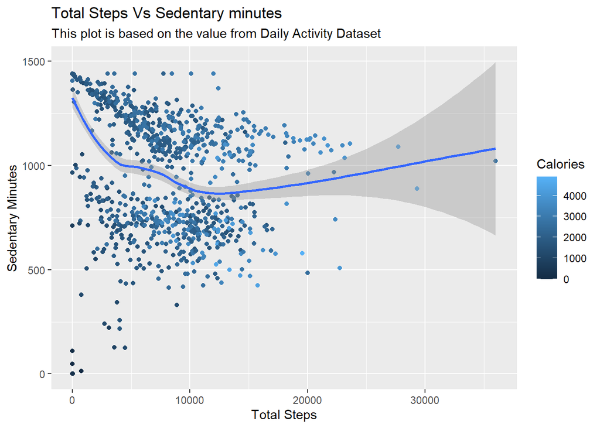

```r
ggplot(data=daily_activity, aes(x=TotalSteps, y=SedentaryMinutes, color = Calories)) + geom_point() + geom_smooth() + labs(title = "Total Steps Vs Sedentary minutes ", subtitle ="This plot is based on the value from Daily Activity Dataset", x = "Total Steps", y="Sedentary Minutes")
```

#### 5.2 Total Steps VS Calories

So we can easily market this to consumers by telling them smart-devices could help them start their journey by measuring how much they’re already moving!

The can also know about their sedentary time.

One can note that sedentary time is not necessarily related to calories burned.

Now I will plot the graph between calories and total steps to see the relationship between them.

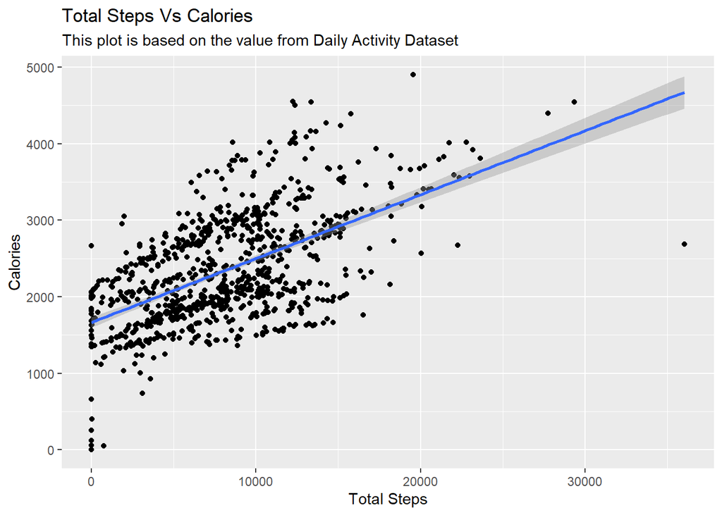

```r
ggplot(data=daily_activity, aes(x=TotalSteps, y = Calories, ))+ geom_point() + stat_smooth(method=lm) +labs(title = "Total Steps Vs Calories ", subtitle ="This plot is based on the value from Daily Activity Dataset", x = "Total Steps", y="Calories")
```

We can clearly see people who took the most total steps tend to burn the most calories. But there is a lot of spread in the value.

Now lets look at the residual or the difference between the observed values and the estimated value

#### 5.3 Calories Burned per Steps

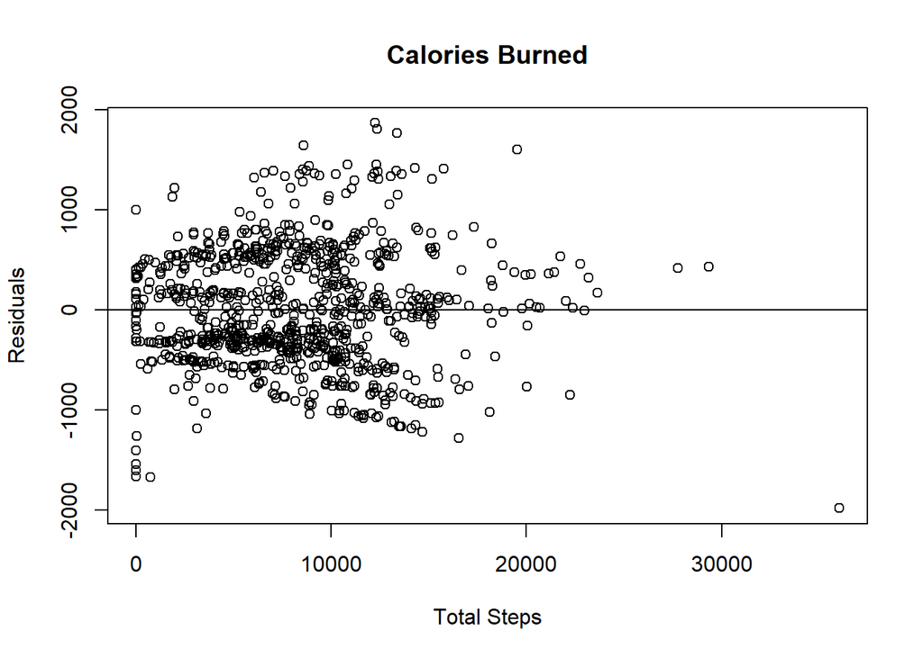

```r
calories.lm <- lm(Calories ~ TotalSteps, data = daily_activity)
calories.res <- resid(calories.lm)

plot(daily_activity$TotalSteps, calories.res, ylab="Residuals",
     xlab = "Total Steps", main = "Calories Burned")
abline(0,0)
```

#### 5.4 Calories Density

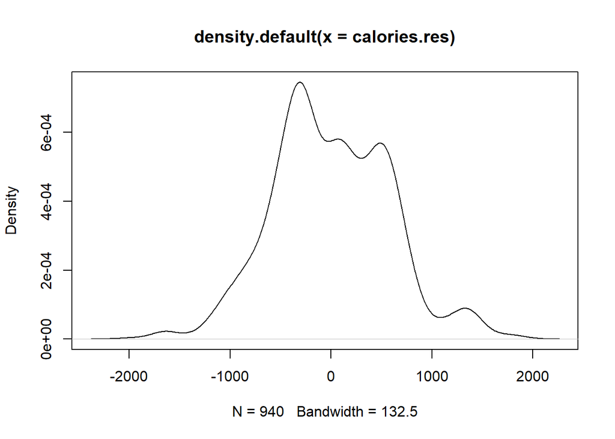

```r
plot(density(calories.res))
```

#### 5.5 Calories Normality

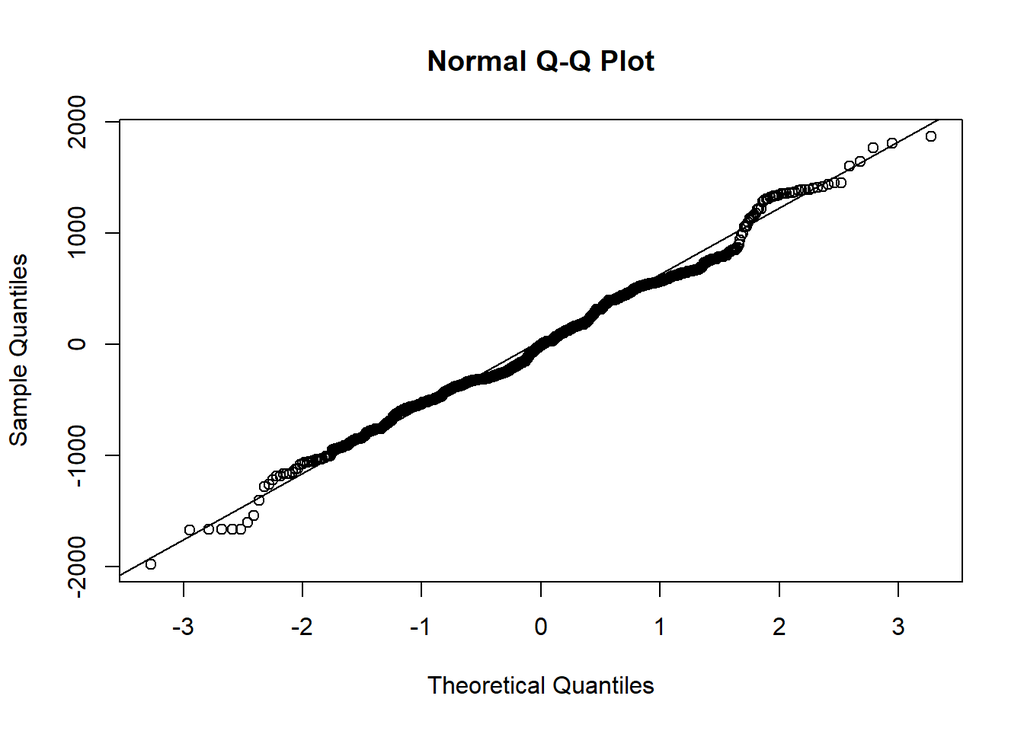

```r
#Checking for normality
qqnorm(calories.res)
qqline(calories.res)
```

So it looks like the spread isn’t as far statistically as we thought.

#### 5.6 Relation between sleep and time in bed

By seeing linear relationship in the graphs we can market that in order to burn calories we do not need to do high-intensity work out, one just needs to walk.

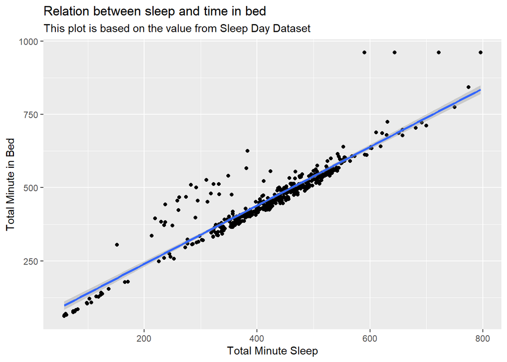

```r
ggplot(data=sleep_day, aes(x=TotalMinutesAsleep, y=TotalTimeInBed)) + geom_point()+ stat_smooth(method=lm) +labs(title = "Relation between sleep and time in bed ", subtitle ="This plot is based on the value from Sleep Day Dataset", x = "Total Minute Sleep", y="Total Minute in Bed")
```

As we can see, there are some outliers, some people that spent a lot of time in bed, but didn’t actually sleep, and then a small batch that slept a whole bunch and spent time in bed

#### 5.7 What’s the relationship between weight and BMI?

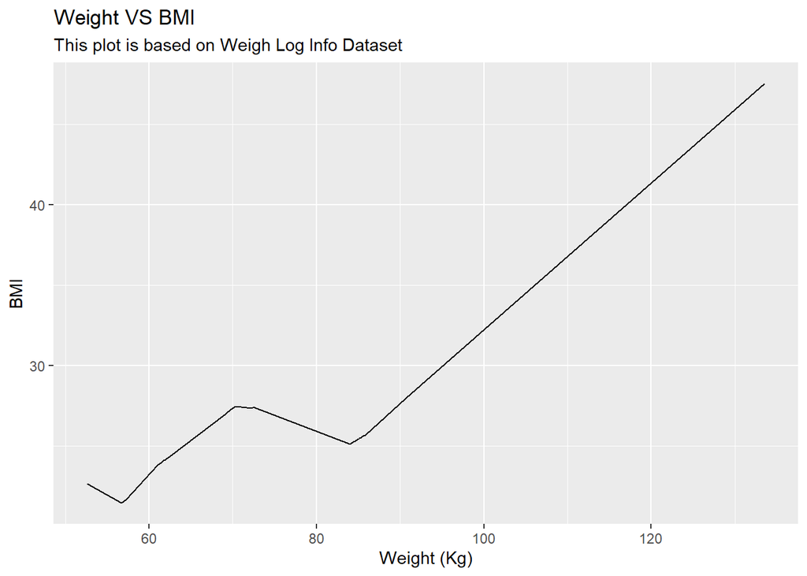

```r
ggplot(data=weight_log_info, aes(x=WeightKg, y=BMI)) + geom_line() + labs(title = "Weight VS BMI ", subtitle ="This plot is based on Weigh Log Info Dataset", x = "Weight (Kg)", y="BMI")
```

#### 5.8 Average User Spend their Day

Next. we look at how the average user spend their day. Going on the average calories spent per hour depending on activities, we assume: 1. Sleep: < 80 calories per hour 2. Normal: >=80, < 150 calories per hour 3. Moderate exercise: >=150, < 400 calories per hour 4. Intense exercise: >= 400 calories per hour

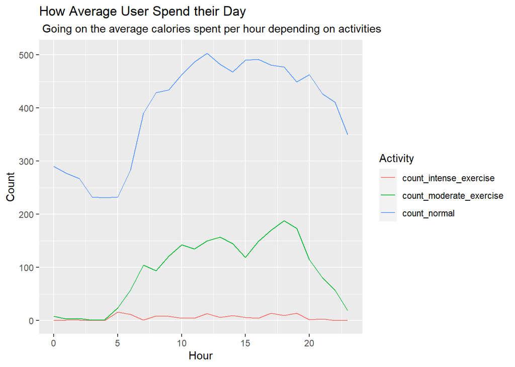

```r
hourlyCalories <- hourly_calories
hourlyCalories$ActivityHour <- mdy_hms(hourlyCalories$ActivityHour)
hourlyCalories$date <- date(hourlyCalories$ActivityHour)
hourlyCalories$hour <- hour(hourlyCalories$ActivityHour)


hourlyCalories$activity <- ifelse(hourlyCalories$Calories < 80, "sleep",
                            ifelse ( (hourlyCalories$Calories >=80 & hourlyCalories$Calories < 150), "normal",
                              ifelse ((hourlyCalories$Calories >=150 & hourlyCalories$Calories < 400), "moderate_exercise", "intense_exercise")))

usage <- count(hourlyCalories, vars= hour)

activity <- hourlyCalories %>%
  group_by(hour) %>%
  summarise(count_sleep = sum(activity == "sleep"), count_normal = sum(activity == "normal"), count_moderate_exercise = sum(activity == "moderate_exercise"), count_intense_exercise = sum(activity=="intense_exercise"))

activity_sorted_long <-
  activity %>%
  gather(c("count_normal","count_moderate_exercise","count_intense_exercise"),key="Activity",value="Count")

ggplot(data = activity_sorted_long, aes (x = hour, y = Count, colour = Activity)) +
  geom_line()+labs(title = "How Average User Spend their Day ", subtitle =" Going on the average calories spent per hour depending on activities", x = "Hour", y="Count")
```

#### 5.9 Significant Usage of Fitbit data

Finally, we try to look at whether the users change their habits over the course of their smart device usage. We do this by tracking their daily calories usage and observing whether they change over time.

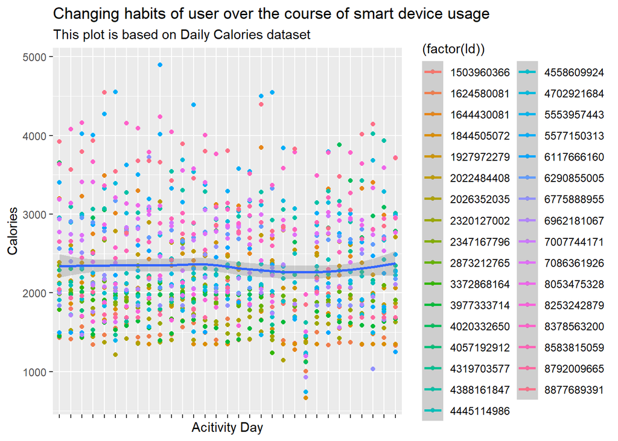

```r
ggplot(data = dailyCalories, aes (x = ActivityDay, y = Calories, colour = (factor(Id)), group = 33)) +
  theme(axis.text.x=element_blank()) +
  geom_point() + geom_smooth() + labs(title = "Changing habits of user over the course of smart device usage ", subtitle ="This plot is based on Daily Calories dataset ", x = "Acitivity Day", y="Calories")
```

We can tell there is little to no significant change in their habits over the average period of 30 days for each test subject.

## 6. Evaluation

#### 6.1 Recommendation

- Marketing for Bellabeat devices should be marketed as a fashion piece or statement with a secondary benefit of tracking health indicators to promote a self-confident, self-sufficient and independent lifestyle rather than a fitness or healthy lifestyle. The focus should be only “Taking good care and pampering yourself” rather than “Staying healthy”.
- The Bellabeat app should focus on social aspects of the users lifestyles and provide minor goals or recommendations to improve their wellness. The app can focus on what the users have done well and allow them to publish these successes on their social media to allow them to portray their excellent usage of the Bellabeat device and an exemplary social media image of themselves.
- One of the most beneficial features of smart wearing devices is to motivate customers to have healthier lifestyles. A peer comparison feature might be developed to encourage customers to increase their active level to improve their health.
- As the data quality is not great based on POCCC review, all the abpve recommendations required further validation.

##### 6.1.2 Two other recommendations are proposed to increase sales:

- since in the scenario of the case study provided to me it was written Bellabeat collects hydration data because they had one product related to hydration check, they are better because fitbit did not have hydration data.
- A marketing strategy can be implemented to tell about sufficient sleep required by body, how it be achieved and how bellabeat can help them keep track of it and improve it.

#### 6.2 Further exploration

- We can see that more people log their calories, steps taken, etc, and fewer users log their sleep data, and only a select few are logging their weight.
- The daily activities of the users are mostly sedentary in nature and few change their lifestyle significant based on the Fitbit data provided. As such, most users do not wear these devices to improve to a healthy lifestyle.

#### 7. Resources

- [Stack Overflow](https://stackoverflow.com/)
- [RDocumentation](https://www.rdocumentation.org/)
- [RStudio](https://community.rstudio.com/) and [Kaggle](https://www.kaggle.com/) community